# Tale of 3 cities

Alex Klaus

2023-06-03

READING THE DATA FOR THE 3 CITIES

PREPROCESSING EVERY CITY DATA USING THE SAME METHODs ON ALL THE DATA.

tibble [10,043 × 7] (S3: tbl_df/tbl/data.frame) $ Date : POSIXct[1:10043], format: “2023-04-30” “2023-04-30” “2023-04-30” … $ Time : chr [1:10043] “22:10:43” “20:41:24” “19:39:35” “19:06:18” … $ id : num [1:10043] 1.65e+18 1.65e+18 1.65e+18 1.65e+18 1.65e+18 … $ content : chr [1:10043] “Sacramento asking for water 🤣#NBA” “@nj3ry @ItsDevMutai I’m selling hope here. Don’t ruin my story 🤣” “We’re getting old 🤣 https://t.co/Crakvgh6Ch” “Mbona yanga mmefuzu na hamna furaja what’s wrong 🤣_KibayasiF” … $ username: chr [1:10043] “Emanzi20” “AbadoJack” “Finmedicalscrub” “miraba_7” … $ like : num [1:10043] 4 2 3 2 2 2 19 3 7 3 … $ retweet : num [1:10043] 1 0 0 0 1 0 5 0 1 0 …

tibble [10,043 × 8] (S3: tbl_df/tbl/data.frame) $ Date : POSIXct[1:10043], format: “2023-04-30” “2023-04-30” “2023-04-30” … $ Time : chr [1:10043] “22:10:43” “20:41:24” “19:39:35” “19:06:18” … $ id : num [1:10043] 1.65e+18 1.65e+18 1.65e+18 1.65e+18 1.65e+18 … $ content : chr [1:10043] “Sacramento asking for water 🤣#NBA” “@nj3ry @ItsDevMutai I’m selling hope here. Don’t ruin my story 🤣” “We’re getting old 🤣 https://t.co/Crakvgh6Ch” “Mbona yanga mmefuzu na hamna furaja what’s wrong 🤣_KibayasiF” … $ username: chr [1:10043] “Emanzi20” “AbadoJack” “Finmedicalscrub” “miraba_7” … $ like : num [1:10043] 4 2 3 2 2 2 19 3 7 3 … $ retweet : num [1:10043] 1 0 0 0 1 0 5 0 1 0 … $ weekday : chr [1:10043] “Sunday” “Sunday” “Sunday” “Sunday” …

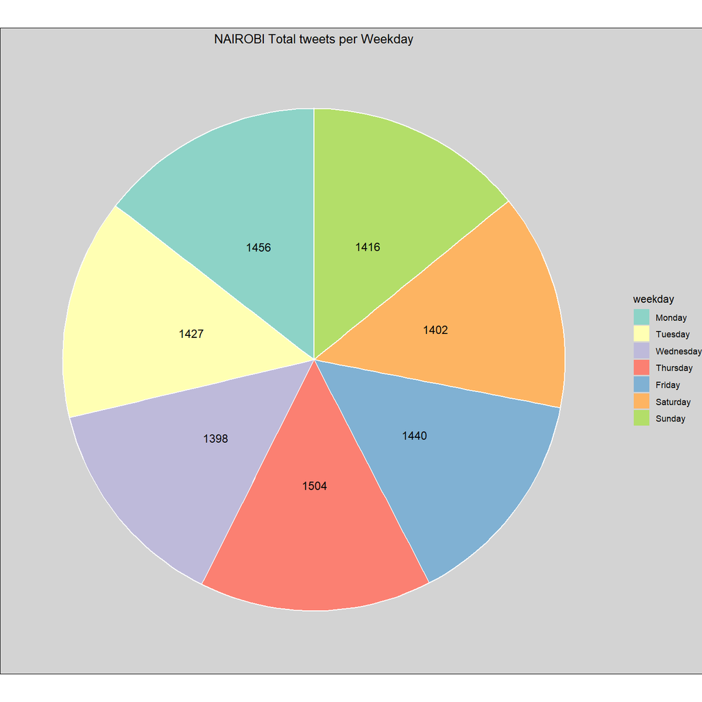

tibble [10,043 × 11] (S3: tbl_df/tbl/data.frame) $ Date : POSIXct[1:10043], format: “2023-04-30” “2023-04-30” “2023-04-30” … $ Time : ‘hms’ num [1:10043] 22:10:43 20:41:24 19:39:35 19:06:18 … ..- attr(*, “units”)= chr “secs” $ id : num [1:10043] 1.65e+18 1.65e+18 1.65e+18 1.65e+18 1.65e+18 … $ content : chr [1:10043] “Sacramento asking for water 🤣#NBA” “@nj3ry @ItsDevMutai I’m selling hope here. Don’t ruin my story 🤣” “We’re getting old 🤣 https://t.co/Crakvgh6Ch” “Mbona yanga mmefuzu na hamna furaja what’s wrong 🤣_KibayasiF” … $ username: chr [1:10043] “Emanzi20” “AbadoJack” “Finmedicalscrub” “miraba_7” … $ like : num [1:10043] 4 2 3 2 2 2 19 3 7 3 … $ retweet : num [1:10043] 1 0 0 0 1 0 5 0 1 0 … $ weekday : chr [1:10043] “Sunday” “Sunday” “Sunday” “Sunday” … $ Hour : int [1:10043] 22 20 19 19 18 17 17 17 16 16 … $ Minute : int [1:10043] 10 41 39 6 30 50 40 4 34 32 … $ Second : num [1:10043] 43 24 35 18 12 19 12 59 45 2 …

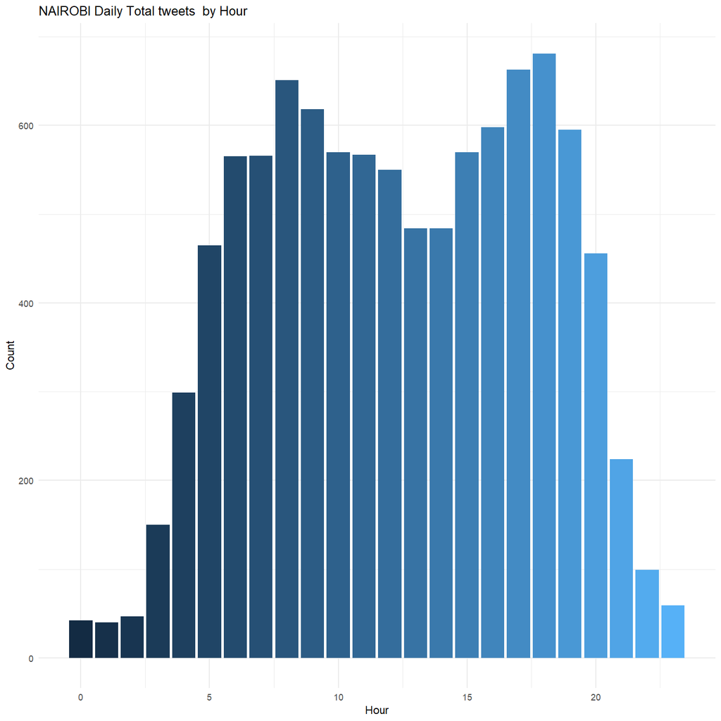

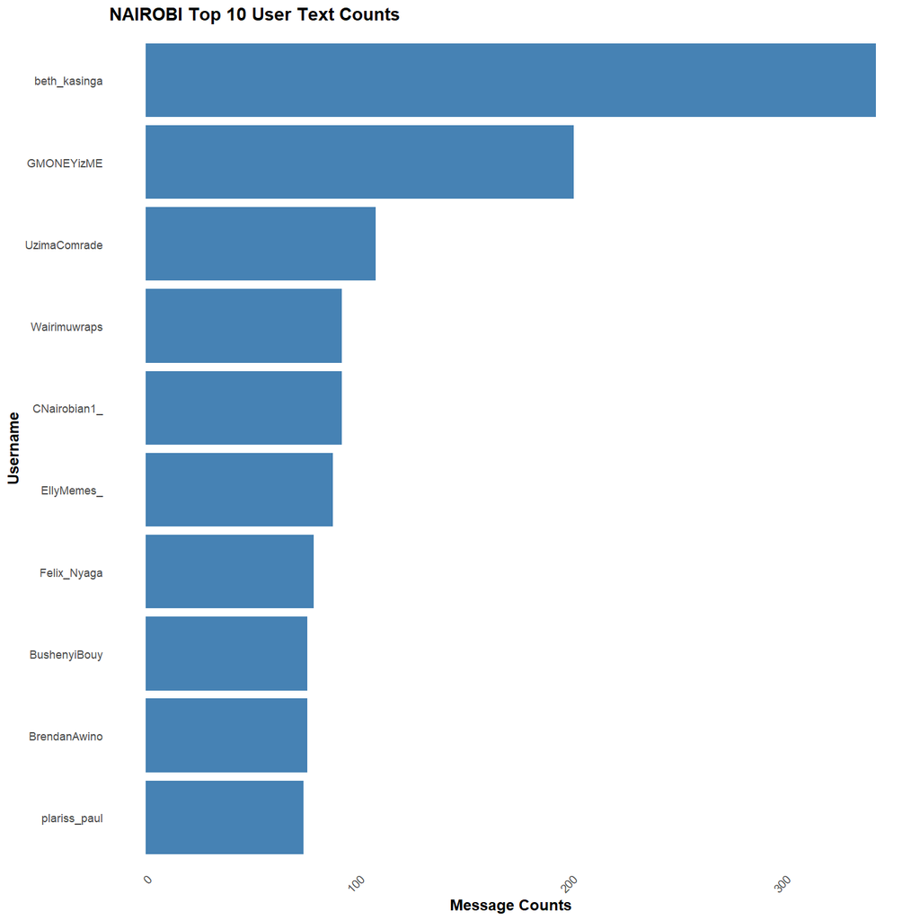

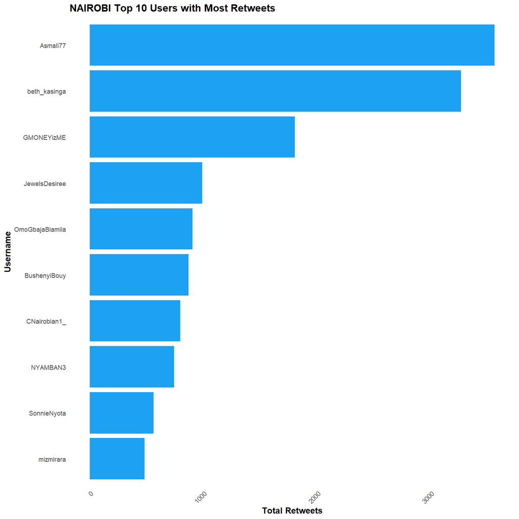

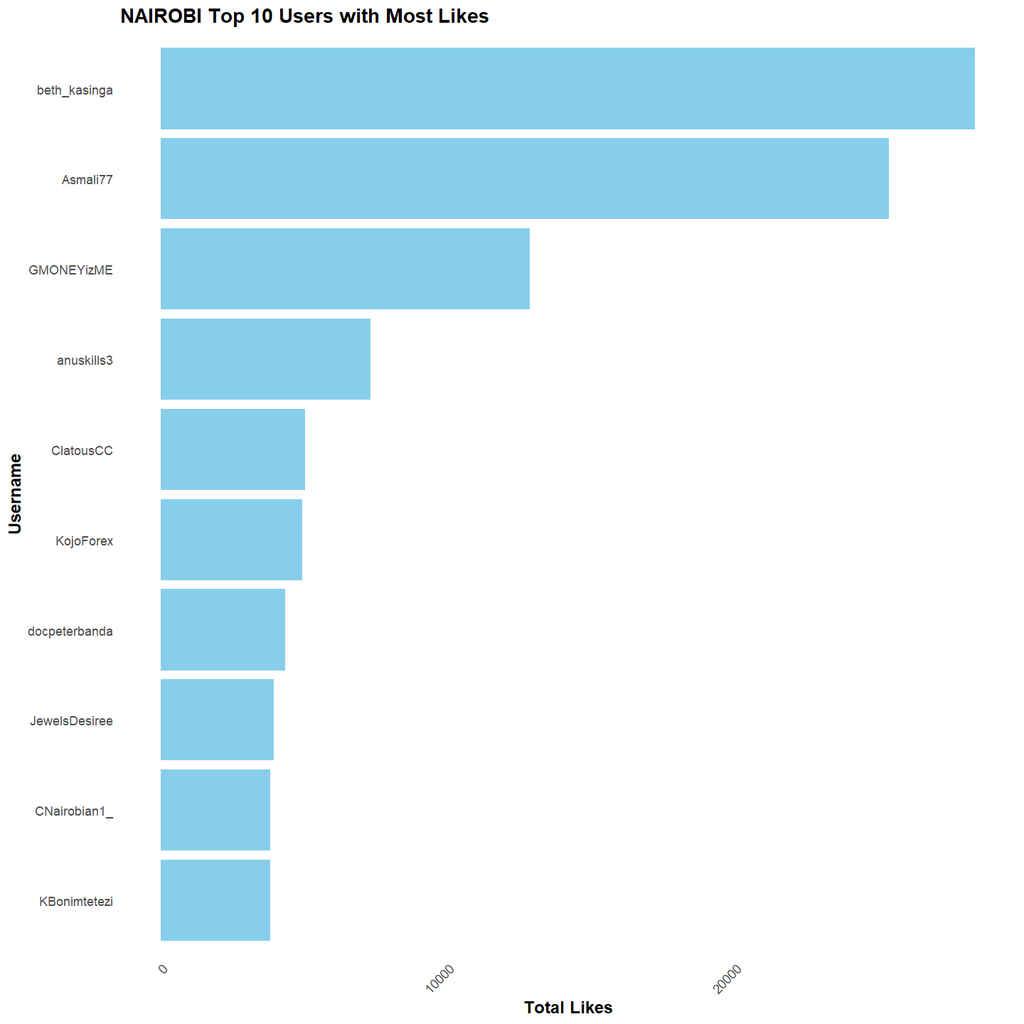

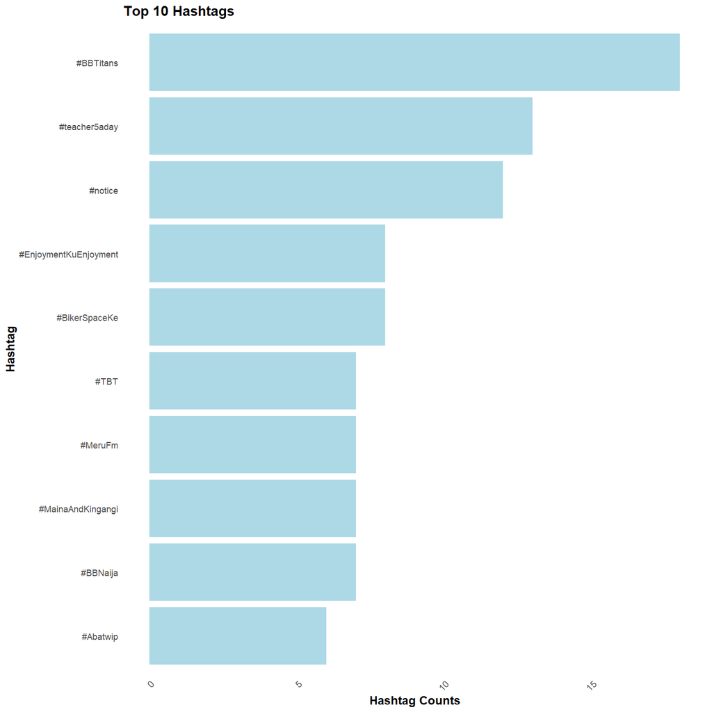

emoticons will just like one dont know wa people now can 334 322 311 296 282 239 239 221 220 218

tibble [14 × 13] (S3: tbl_df/tbl/data.frame) $ Date : POSIXct[1:14], format: “2023-04-18” “2023-04-11” “2023-03-07” … $ Time : ‘hms’ num [1:14] 20:50:38 07:07:44 07:54:40 08:49:42 … ..- attr(*, “units”)= chr “secs” $ id : num [1:14] 1.65e+18 1.65e+18 1.63e+18 1.62e+18 1.62e+18 … $ content : chr [1:14] “Wachezaji wa YouTube 🤣 https://t.co/b0FMYhpIsL” “@Gideon_Kitheka Maybe MITHIKA from agriculture docket… 😄 🤣 😂 mama miradi, she has a lot of cash… ht”| **truncated** “Mambo tunayopenda kuskia 🤣🌚” “Weh! This boy can lift heavy stuff 🤣🙌🏾” … $ username : chr [1:14] “INFLUENCERjr” “emdabliu2014” “INFLUENCERjr” “YourFrenchFry” … $ like : num [1:14] 222 61 74 335 74 63 58 52 54 70 … $ retweet : num [1:14] 1 1 1 1 1 1 1 1 1 1 … $ weekday : chr [1:14] “Tuesday” “Tuesday” “Tuesday” “Monday” … $ Hour : int [1:14] 20 7 7 8 6 17 19 21 6 20 … $ Minute : int [1:14] 50 7 54 49 24 54 24 0 0 48 … $ Second : num [1:14] 38 44 40 42 19 41 17 19 50 53 … $ cleaned_content: chr [1:14] “wachezaji wa youtube 🤣” “maybe mithika from agriculture docket 😄 🤣 😂 ma mama miradi she has a lot of cash” “mambo tunayopenda kuskia 🤣🌚” “weh this boy can lift heavy stuff 🤣🙌🏾” … $ word_count : int [1:14] 4 18 4 8 25 3 3 2 7 11 …

[figure not shown]